# Risk Factor Analysis

## Outcome Variable

**Outcome Variable:** sstunted

## Predictor Variables

**Intervention Variable:** hhwealth_quart

**Adjustment Set:**

- arm
- sex
- W_mage
- meducyrs
- feducyrs
- W_gagebrth
- W_birthwt
- W_birthlen
- W_nchldlt5
- W_parity
- delta_W_mage
- delta_meducyrs
- delta_feducyrs
- delta_W_gagebrth
- delta_W_birthwt
- delta_W_birthlen
- delta_W_nchldlt5
- delta_W_parity

## Stratifying Variables

The analysis was stratified on these variable(s):

- agecat
- studyid
- country

## Data Summary

| agecat | studyid | country | hhwealth_quart | sstunted | n_cell | n |
| --- | --- | --- | --- | --- | --- | --- |
| Birth | ki0047075b-MAL-ED | BANGLADESH | Wealth Q4 | 0 | 21 | 82 |
| Birth | ki0047075b-MAL-ED | BANGLADESH | Wealth Q4 | 1 | 0 | 82 |
| Birth | ki0047075b-MAL-ED | BANGLADESH | Wealth Q1 | 0 | 18 | 82 |
| Birth | ki0047075b-MAL-ED | BANGLADESH | Wealth Q1 | 1 | 3 | 82 |
| Birth | ki0047075b-MAL-ED | BANGLADESH | Wealth Q2 | 0 | 19 | 82 |
| Birth | ki0047075b-MAL-ED | BANGLADESH | Wealth Q2 | 1 | 1 | 82 |
| Birth | ki0047075b-MAL-ED | BANGLADESH | Wealth Q3 | 0 | 20 | 82 |
| Birth | ki0047075b-MAL-ED | BANGLADESH | Wealth Q3 | 1 | 0 | 82 |
| Birth | ki0047075b-MAL-ED | INDIA | Wealth Q4 | 0 | 11 | 55 |
| Birth | ki0047075b-MAL-ED | INDIA | Wealth Q4 | 1 | 1 | 55 |
| Birth | ki0047075b-MAL-ED | INDIA | Wealth Q1 | 0 | 17 | 55 |
| Birth | ki0047075b-MAL-ED | INDIA | Wealth Q1 | 1 | 0 | 55 |
| Birth | ki0047075b-MAL-ED | INDIA | Wealth Q2 | 0 | 15 | 55 |
| Birth | ki0047075b-MAL-ED | INDIA | Wealth Q2 | 1 | 0 | 55 |
| Birth | ki0047075b-MAL-ED | INDIA | Wealth Q3 | 0 | 9 | 55 |
| Birth | ki0047075b-MAL-ED | INDIA | Wealth Q3 | 1 | 2 | 55 |
| Birth | ki0047075b-MAL-ED | NEPAL | Wealth Q4 | 0 | 9 | 31 |
| Birth | ki0047075b-MAL-ED | NEPAL | Wealth Q4 | 1 | 0 | 31 |
| Birth | ki0047075b-MAL-ED | NEPAL | Wealth Q1 | 0 | 8 | 31 |
| Birth | ki0047075b-MAL-ED | NEPAL | Wealth Q1 | 1 | 0 | 31 |
| Birth | ki0047075b-MAL-ED | NEPAL | Wealth Q2 | 0 | 6 | 31 |
| Birth | ki0047075b-MAL-ED | NEPAL | Wealth Q2 | 1 | 1 | 31 |
| Birth | ki0047075b-MAL-ED | NEPAL | Wealth Q3 | 0 | 7 | 31 |
| Birth | ki0047075b-MAL-ED | NEPAL | Wealth Q3 | 1 | 0 | 31 |
| Birth | ki0047075b-MAL-ED | PERU | Wealth Q4 | 0 | 10 | 36 |
| Birth | ki0047075b-MAL-ED | PERU | Wealth Q4 | 1 | 0 | 36 |
| Birth | ki0047075b-MAL-ED | PERU | Wealth Q1 | 0 | 9 | 36 |
| Birth | ki0047075b-MAL-ED | PERU | Wealth Q1 | 1 | 0 | 36 |
| Birth | ki0047075b-MAL-ED | PERU | Wealth Q2 | 0 | 9 | 36 |
| Birth | ki0047075b-MAL-ED | PERU | Wealth Q2 | 1 | 0 | 36 |

[output cut: 346 more lines]

The following strata were considered:

- agecat: 24 months, studyid: ki0047075b-MAL-ED, country: BANGLADESH
- agecat: 24 months, studyid: ki0047075b-MAL-ED, country: INDIA
- agecat: 24 months, studyid: ki0047075b-MAL-ED, country: NEPAL
- agecat: 24 months, studyid: ki0047075b-MAL-ED, country: PERU
- agecat: 24 months, studyid: ki0047075b-MAL-ED, country: SOUTH AFRICA
- agecat: 24 months, studyid: ki0047075b-MAL-ED, country: TANZANIA, UNITED REPUBLIC OF
- agecat: 24 months, studyid: ki1000108-CMC-V-BCS-2002, country: INDIA
- agecat: 24 months, studyid: ki1000108-IRC, country: INDIA
- agecat: 24 months, studyid: ki1017093b-PROVIDE, country: BANGLADESH
- agecat: 24 months, studyid: ki1066203-TanzaniaChild2, country: TANZANIA, UNITED REPUBLIC OF
- agecat: 24 months, studyid: ki1113344-GMS-Nepal, country: NEPAL
- agecat: 24 months, studyid: ki1114097-CONTENT, country: PERU
- agecat: 24 months, studyid: ki1135781-COHORTS, country: GUATEMALA
- agecat: 24 months, studyid: ki1135781-COHORTS, country: PHILIPPINES
- agecat: 24 months, studyid: ki1148112-LCNI-5, country: MALAWI
- agecat: 24 months, studyid: kiGH5241-JiVitA-3, country: BANGLADESH
- agecat: 24 months, studyid: kiGH5241-JiVitA-4, country: BANGLADESH
- agecat: 6 months, studyid: ki0047075b-MAL-ED, country: BANGLADESH
- agecat: 6 months, studyid: ki0047075b-MAL-ED, country: INDIA
- agecat: 6 months, studyid: ki0047075b-MAL-ED, country: NEPAL
- agecat: 6 months, studyid: ki0047075b-MAL-ED, country: PERU
- agecat: 6 months, studyid: ki0047075b-MAL-ED, country: SOUTH AFRICA
- agecat: 6 months, studyid: ki0047075b-MAL-ED, country: TANZANIA, UNITED REPUBLIC OF
- agecat: 6 months, studyid: ki1000108-CMC-V-BCS-2002, country: INDIA
- agecat: 6 months, studyid: ki1000108-IRC, country: INDIA
- agecat: 6 months, studyid: ki1017093b-PROVIDE, country: BANGLADESH
- agecat: 6 months, studyid: ki1066203-TanzaniaChild2, country: TANZANIA, UNITED REPUBLIC OF
- agecat: 6 months, studyid: ki1113344-GMS-Nepal, country: NEPAL
- agecat: 6 months, studyid: ki1114097-CONTENT, country: PERU
- agecat: 6 months, studyid: ki1135781-COHORTS, country: GUATEMALA
- agecat: 6 months, studyid: ki1135781-COHORTS, country: PHILIPPINES
- agecat: 6 months, studyid: ki1148112-LCNI-5, country: MALAWI
- agecat: 6 months, studyid: kiGH5241-JiVitA-3, country: BANGLADESH
- agecat: 6 months, studyid: kiGH5241-JiVitA-4, country: BANGLADESH
- agecat: Birth, studyid: ki0047075b-MAL-ED, country: BANGLADESH
- agecat: Birth, studyid: ki0047075b-MAL-ED, country: INDIA
- agecat: Birth, studyid: ki0047075b-MAL-ED, country: NEPAL
- agecat: Birth, studyid: ki0047075b-MAL-ED, country: PERU
- agecat: Birth, studyid: ki0047075b-MAL-ED, country: SOUTH AFRICA
- agecat: Birth, studyid: ki0047075b-MAL-ED, country: TANZANIA, UNITED REPUBLIC OF
- agecat: Birth, studyid: ki1000108-CMC-V-BCS-2002, country: INDIA
- agecat: Birth, studyid: ki1000108-IRC, country: INDIA
- agecat: Birth, studyid: ki1114097-CONTENT, country: PERU
- agecat: Birth, studyid: ki1135781-COHORTS, country: GUATEMALA
- agecat: Birth, studyid: ki1135781-COHORTS, country: PHILIPPINES
- agecat: Birth, studyid: kiGH5241-JiVitA-3, country: BANGLADESH
- agecat: Birth, studyid: kiGH5241-JiVitA-4, country: BANGLADESH

### Dropped Strata

Some strata were dropped due to rare outcomes:

- agecat: Birth, studyid: ki0047075b-MAL-ED, country: BANGLADESH
- agecat: Birth, studyid: ki0047075b-MAL-ED, country: INDIA
- agecat: Birth, studyid: ki0047075b-MAL-ED, country: NEPAL
- agecat: Birth, studyid: ki0047075b-MAL-ED, country: PERU
- agecat: Birth, studyid: ki0047075b-MAL-ED, country: SOUTH AFRICA
- agecat: Birth, studyid: ki0047075b-MAL-ED, country: TANZANIA, UNITED REPUBLIC OF
- agecat: Birth, studyid: ki1000108-CMC-V-BCS-2002, country: INDIA
- agecat: Birth, studyid: ki1000108-IRC, country: INDIA
- agecat: Birth, studyid: ki1114097-CONTENT, country: PERU
- agecat: Birth, studyid: ki1135781-COHORTS, country: GUATEMALA
- agecat: 6 months, studyid: ki0047075b-MAL-ED, country: BANGLADESH
- agecat: 6 months, studyid: ki0047075b-MAL-ED, country: INDIA
- agecat: 6 months, studyid: ki0047075b-MAL-ED, country: NEPAL
- agecat: 6 months, studyid: ki0047075b-MAL-ED, country: PERU
- agecat: 6 months, studyid: ki0047075b-MAL-ED, country: SOUTH AFRICA
- agecat: 6 months, studyid: ki0047075b-MAL-ED, country: TANZANIA, UNITED REPUBLIC OF
- agecat: 6 months, studyid: ki1000108-CMC-V-BCS-2002, country: INDIA
- agecat: 6 months, studyid: ki1000108-IRC, country: INDIA
- agecat: 6 months, studyid: ki1017093b-PROVIDE, country: BANGLADESH
- agecat: 6 months, studyid: ki1066203-TanzaniaChild2, country: TANZANIA, UNITED REPUBLIC OF
- agecat: 6 months, studyid: ki1113344-GMS-Nepal, country: NEPAL
- agecat: 6 months, studyid: ki1114097-CONTENT, country: PERU
- agecat: 24 months, studyid: ki0047075b-MAL-ED, country: BANGLADESH
- agecat: 24 months, studyid: ki0047075b-MAL-ED, country: INDIA
- agecat: 24 months, studyid: ki0047075b-MAL-ED, country: NEPAL
- agecat: 24 months, studyid: ki0047075b-MAL-ED, country: PERU
- agecat: 24 months, studyid: ki0047075b-MAL-ED, country: SOUTH AFRICA
- agecat: 24 months, studyid: ki0047075b-MAL-ED, country: TANZANIA, UNITED REPUBLIC OF
- agecat: 24 months, studyid: ki1066203-TanzaniaChild2, country: TANZANIA, UNITED REPUBLIC OF
- agecat: 24 months, studyid: ki1114097-CONTENT, country: PERU

## Methods Detail

We’re interested in the causal parameters $E[Y_a]$ for all values of $a \in \mathcal{A}$. These parameters represent the mean outcome if, possibly contrary to fact, we intervened to set all units to have $A=a$. Under the randomization and positivity assumptions, these are identified by the statistical parameters $\psi_a=E_W[E_{Y|A,W}(Y|A=a,W)]$. In addition, we’re interested in the mean of $Y$, $E[Y]$ under no intervention (the observed mean). We will estimate these parameters by using SuperLearner to fit the relevant likelihood factors – $E_{Y|A,W}(Y|A=a,W)$ and $p(A=a|W)$, and then updating our likelihood fit using a joint TMLE.

For unadjusted analyses ($W=\{\}$), initial likelihoods were estimated using Lrnr_glm to estimate the simple $E(Y|A)$ and Lrnr_mean to estimate $p(A)$. For adjusted analyses, a small library containing Lrnr_glmnet, Lrnr_xgboost, and Lrnr_mean was used.

Having estimated these parameters, we will then use the delta method to estimate relative risks and attributable risks relative to a prespecified baseline level of $A$.

# Results Detail

## Results Plots

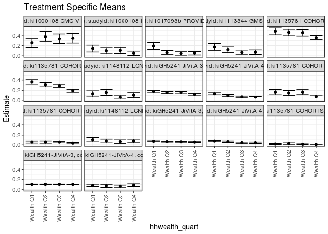

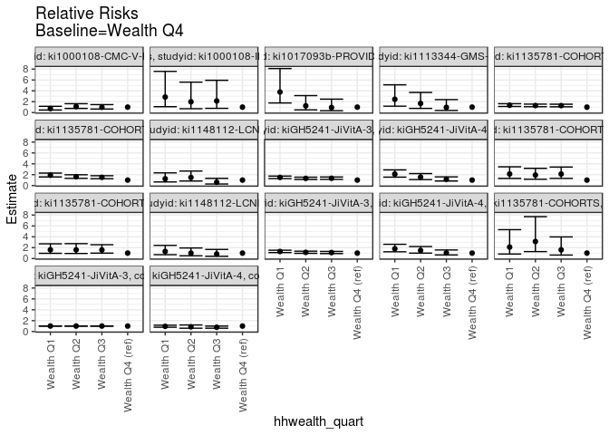

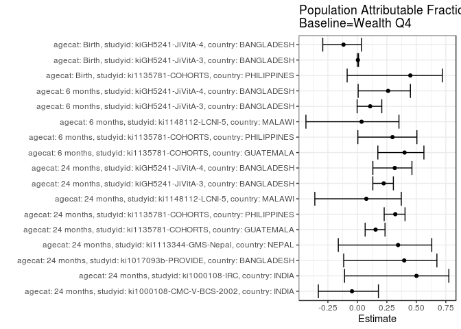

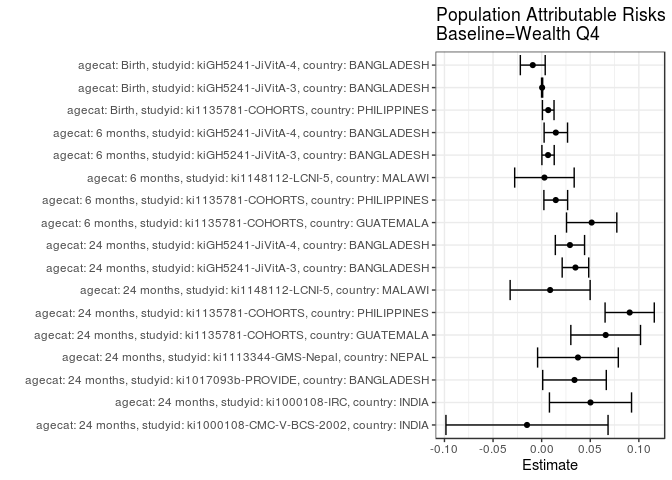

## Results Table

### Parameter: TSM

| agecat | studyid | country | intervention_level | baseline_level | estimate | ci_lower | ci_upper |
| --- | --- | --- | --- | --- | --- | --- | --- |
| Birth | ki1135781-COHORTS | PHILIPPINES | Wealth Q4 | NA | 0.0083135 | 0.0021795 | 0.0144475 |
| Birth | ki1135781-COHORTS | PHILIPPINES | Wealth Q1 | NA | 0.0174672 | 0.0076695 | 0.0272650 |
| Birth | ki1135781-COHORTS | PHILIPPINES | Wealth Q2 | NA | 0.0260223 | 0.0125676 | 0.0394771 |
| Birth | ki1135781-COHORTS | PHILIPPINES | Wealth Q3 | NA | 0.0132383 | 0.0060886 | 0.0203880 |
| Birth | kiGH5241-JiVitA-3 | BANGLADESH | Wealth Q4 | NA | 0.1036879 | 0.0989877 | 0.1083882 |
| Birth | kiGH5241-JiVitA-3 | BANGLADESH | Wealth Q1 | NA | 0.1044121 | 0.0997308 | 0.1090934 |
| Birth | kiGH5241-JiVitA-3 | BANGLADESH | Wealth Q2 | NA | 0.1042417 | 0.0995677 | 0.1089158 |
| Birth | kiGH5241-JiVitA-3 | BANGLADESH | Wealth Q3 | NA | 0.1042608 | 0.0995434 | 0.1089782 |
| Birth | kiGH5241-JiVitA-4 | BANGLADESH | Wealth Q4 | NA | 0.0869978 | 0.0602029 | 0.1137927 |
| Birth | kiGH5241-JiVitA-4 | BANGLADESH | Wealth Q1 | NA | 0.0832089 | 0.0595583 | 0.1068596 |
| Birth | kiGH5241-JiVitA-4 | BANGLADESH | Wealth Q2 | NA | 0.0744930 | 0.0445775 | 0.1044085 |
| Birth | kiGH5241-JiVitA-4 | BANGLADESH | Wealth Q3 | NA | 0.0679605 | 0.0466525 | 0.0892685 |
| 6 months | ki1135781-COHORTS | GUATEMALA | Wealth Q4 | NA | 0.0771914 | 0.0489124 | 0.1054704 |
| 6 months | ki1135781-COHORTS | GUATEMALA | Wealth Q1 | NA | 0.1640761 | 0.1115550 | 0.2165972 |
| 6 months | ki1135781-COHORTS | GUATEMALA | Wealth Q2 | NA | 0.1480800 | 0.0973185 | 0.1988414 |
| 6 months | ki1135781-COHORTS | GUATEMALA | Wealth Q3 | NA | 0.1634649 | 0.1138844 | 0.2130453 |
| 6 months | ki1135781-COHORTS | PHILIPPINES | Wealth Q4 | NA | 0.0342319 | 0.0210133 | 0.0474505 |
| 6 months | ki1135781-COHORTS | PHILIPPINES | Wealth Q1 | NA | 0.0551632 | 0.0359320 | 0.0743943 |
| 6 months | ki1135781-COHORTS | PHILIPPINES | Wealth Q2 | NA | 0.0545490 | 0.0338672 | 0.0752308 |
| 6 months | ki1135781-COHORTS | PHILIPPINES | Wealth Q3 | NA | 0.0542331 | 0.0395017 | 0.0689645 |
| 6 months | ki1148112-LCNI-5 | MALAWI | Wealth Q4 | NA | 0.0768005 | 0.0414148 | 0.1121861 |
| 6 months | ki1148112-LCNI-5 | MALAWI | Wealth Q1 | NA | 0.1002867 | 0.0588327 | 0.1417406 |
| 6 months | ki1148112-LCNI-5 | MALAWI | Wealth Q2 | NA | 0.0762233 | 0.0391574 | 0.1132891 |
| 6 months | ki1148112-LCNI-5 | MALAWI | Wealth Q3 | NA | 0.0638170 | 0.0298823 | 0.0977517 |
| 6 months | kiGH5241-JiVitA-3 | BANGLADESH | Wealth Q4 | NA | 0.0540535 | 0.0468164 | 0.0612905 |
| 6 months | kiGH5241-JiVitA-3 | BANGLADESH | Wealth Q1 | NA | 0.0700061 | 0.0620023 | 0.0780100 |
| 6 months | kiGH5241-JiVitA-3 | BANGLADESH | Wealth Q2 | NA | 0.0613366 | 0.0538953 | 0.0687780 |
| 6 months | kiGH5241-JiVitA-3 | BANGLADESH | Wealth Q3 | NA | 0.0590431 | 0.0518304 | 0.0662559 |
| 6 months | kiGH5241-JiVitA-4 | BANGLADESH | Wealth Q4 | NA | 0.0413706 | 0.0274284 | 0.0553127 |
| 6 months | kiGH5241-JiVitA-4 | BANGLADESH | Wealth Q1 | NA | 0.0744777 | 0.0614574 | 0.0874979 |
| 6 months | kiGH5241-JiVitA-4 | BANGLADESH | Wealth Q2 | NA | 0.0612245 | 0.0474280 | 0.0750211 |
| 6 months | kiGH5241-JiVitA-4 | BANGLADESH | Wealth Q3 | NA | 0.0423193 | 0.0308150 | 0.0538236 |
| 24 months | ki1000108-CMC-V-BCS-2002 | INDIA | Wealth Q4 | NA | 0.3457202 | 0.2489420 | 0.4424984 |
| 24 months | ki1000108-CMC-V-BCS-2002 | INDIA | Wealth Q1 | NA | 0.2532690 | 0.1631981 | 0.3433400 |
| 24 months | ki1000108-CMC-V-BCS-2002 | INDIA | Wealth Q2 | NA | 0.3827224 | 0.2825195 | 0.4829254 |
| 24 months | ki1000108-CMC-V-BCS-2002 | INDIA | Wealth Q3 | NA | 0.3367329 | 0.2387065 | 0.4347593 |
| 24 months | ki1000108-IRC | INDIA | Wealth Q4 | NA | 0.0500000 | 0.0072313 | 0.0927687 |
| 24 months | ki1000108-IRC | INDIA | Wealth Q1 | NA | 0.1428571 | 0.0758436 | 0.2098707 |
| 24 months | ki1000108-IRC | INDIA | Wealth Q2 | NA | 0.0990099 | 0.0406898 | 0.1573300 |
| 24 months | ki1000108-IRC | INDIA | Wealth Q3 | NA | 0.1067961 | 0.0470769 | 0.1665153 |
| 24 months | ki1017093b-PROVIDE | BANGLADESH | Wealth Q4 | NA | 0.0512821 | 0.0166391 | 0.0859250 |
| 24 months | ki1017093b-PROVIDE | BANGLADESH | Wealth Q1 | NA | 0.1937984 | 0.1255288 | 0.2620681 |
| 24 months | ki1017093b-PROVIDE | BANGLADESH | Wealth Q2 | NA | 0.0633803 | 0.0232715 | 0.1034891 |
| 24 months | ki1017093b-PROVIDE | BANGLADESH | Wealth Q3 | NA | 0.0469799 | 0.0129751 | 0.0809846 |
| 24 months | ki1113344-GMS-Nepal | NEPAL | Wealth Q4 | NA | 0.0708661 | 0.0261936 | 0.1155387 |
| 24 months | ki1113344-GMS-Nepal | NEPAL | Wealth Q1 | NA | 0.1732283 | 0.1073437 | 0.2391130 |
| 24 months | ki1113344-GMS-Nepal | NEPAL | Wealth Q2 | NA | 0.1190476 | 0.0624452 | 0.1756500 |
| 24 months | ki1113344-GMS-Nepal | NEPAL | Wealth Q3 | NA | 0.0672269 | 0.0221899 | 0.1122639 |
| 24 months | ki1135781-COHORTS | GUATEMALA | Wealth Q4 | NA | 0.3609162 | 0.3153754 | 0.4064570 |
| 24 months | ki1135781-COHORTS | GUATEMALA | Wealth Q1 | NA | 0.4867193 | 0.4183130 | 0.5551255 |
| 24 months | ki1135781-COHORTS | GUATEMALA | Wealth Q2 | NA | 0.4642621 | 0.3993014 | 0.5292228 |
| 24 months | ki1135781-COHORTS | GUATEMALA | Wealth Q3 | NA | 0.4590199 | 0.3943832 | 0.5236566 |
| 24 months | ki1135781-COHORTS | PHILIPPINES | Wealth Q4 | NA | 0.1912369 | 0.1632780 | 0.2191959 |
| 24 months | ki1135781-COHORTS | PHILIPPINES | Wealth Q1 | NA | 0.3637480 | 0.3208559 | 0.4066402 |
| 24 months | ki1135781-COHORTS | PHILIPPINES | Wealth Q2 | NA | 0.3103179 | 0.2671635 | 0.3534723 |
| 24 months | ki1135781-COHORTS | PHILIPPINES | Wealth Q3 | NA | 0.2887958 | 0.2585404 | 0.3190512 |
| 24 months | ki1148112-LCNI-5 | MALAWI | Wealth Q4 | NA | 0.1062500 | 0.0584598 | 0.1540402 |
| 24 months | ki1148112-LCNI-5 | MALAWI | Wealth Q1 | NA | 0.1317829 | 0.0733611 | 0.1902048 |
| 24 months | ki1148112-LCNI-5 | MALAWI | Wealth Q2 | NA | 0.1575342 | 0.0983898 | 0.2166787 |
| 24 months | ki1148112-LCNI-5 | MALAWI | Wealth Q3 | NA | 0.0647482 | 0.0238035 | 0.1056929 |
| 24 months | kiGH5241-JiVitA-3 | BANGLADESH | Wealth Q4 | NA | 0.1210907 | 0.1058862 | 0.1362952 |
| 24 months | kiGH5241-JiVitA-3 | BANGLADESH | Wealth Q1 | NA | 0.1812589 | 0.1643263 | 0.1981915 |
| 24 months | kiGH5241-JiVitA-3 | BANGLADESH | Wealth Q2 | NA | 0.1591517 | 0.1421051 | 0.1761984 |
| 24 months | kiGH5241-JiVitA-3 | BANGLADESH | Wealth Q3 | NA | 0.1618516 | 0.1452392 | 0.1784640 |
| 24 months | kiGH5241-JiVitA-4 | BANGLADESH | Wealth Q4 | NA | 0.0627346 | 0.0457390 | 0.0797301 |
| 24 months | kiGH5241-JiVitA-4 | BANGLADESH | Wealth Q1 | NA | 0.1322609 | 0.1115296 | 0.1529921 |
| 24 months | kiGH5241-JiVitA-4 | BANGLADESH | Wealth Q2 | NA | 0.0973346 | 0.0766358 | 0.1180335 |
| 24 months | kiGH5241-JiVitA-4 | BANGLADESH | Wealth Q3 | NA | 0.0722154 | 0.0571095 | 0.0873214 |

### Parameter: E(Y)

| agecat | studyid | country | intervention_level | baseline_level | estimate | ci_lower | ci_upper |
| --- | --- | --- | --- | --- | --- | --- | --- |
| Birth | ki1135781-COHORTS | PHILIPPINES | NA | NA | 0.0150869 | 0.0107594 | 0.0194144 |
| Birth | kiGH5241-JiVitA-3 | BANGLADESH | NA | NA | 0.1041645 | 0.0994900 | 0.1088391 |
| Birth | kiGH5241-JiVitA-4 | BANGLADESH | NA | NA | 0.0778589 | 0.0559066 | 0.0998111 |
| 6 months | ki1135781-COHORTS | GUATEMALA | NA | NA | 0.1286486 | 0.1070607 | 0.1502366 |
| 6 months | ki1135781-COHORTS | PHILIPPINES | NA | NA | 0.0487445 | 0.0406327 | 0.0568562 |
| 6 months | ki1148112-LCNI-5 | MALAWI | NA | NA | 0.0796569 | 0.0610679 | 0.0982459 |
| 6 months | kiGH5241-JiVitA-3 | BANGLADESH | NA | NA | 0.0606439 | 0.0567894 | 0.0644985 |
| 6 months | kiGH5241-JiVitA-4 | BANGLADESH | NA | NA | 0.0559585 | 0.0491999 | 0.0627172 |
| 24 months | ki1000108-CMC-V-BCS-2002 | INDIA | NA | NA | 0.3306452 | 0.2827744 | 0.3785159 |
| 24 months | ki1000108-IRC | INDIA | NA | NA | 0.1002445 | 0.0711031 | 0.1293859 |
| 24 months | ki1017093b-PROVIDE | BANGLADESH | NA | NA | 0.0850694 | 0.0622663 | 0.1078726 |
| 24 months | ki1113344-GMS-Nepal | NEPAL | NA | NA | 0.1082164 | 0.0809323 | 0.1355005 |
| 24 months | ki1135781-COHORTS | GUATEMALA | NA | NA | 0.4267823 | 0.3966784 | 0.4568861 |
| 24 months | ki1135781-COHORTS | PHILIPPINES | NA | NA | 0.2817996 | 0.2639639 | 0.2996353 |
| 24 months | ki1148112-LCNI-5 | MALAWI | NA | NA | 0.1149826 | 0.0888632 | 0.1411019 |
| 24 months | kiGH5241-JiVitA-3 | BANGLADESH | NA | NA | 0.1558622 | 0.1471181 | 0.1646064 |
| 24 months | kiGH5241-JiVitA-4 | BANGLADESH | NA | NA | 0.0918475 | 0.0824775 | 0.1012175 |

### Parameter: RR

| agecat | studyid | country | intervention_level | baseline_level | estimate | ci_lower | ci_upper |
| --- | --- | --- | --- | --- | --- | --- | --- |
| Birth | ki1135781-COHORTS | PHILIPPINES | Wealth Q4 | Wealth Q4 | 1.0000000 | 1.0000000 | 1.000000 |
| Birth | ki1135781-COHORTS | PHILIPPINES | Wealth Q1 | Wealth Q4 | 2.1010605 | 0.8316064 | 5.308347 |
| Birth | ki1135781-COHORTS | PHILIPPINES | Wealth Q2 | Wealth Q4 | 3.1301115 | 1.2713841 | 7.706246 |
| Birth | ki1135781-COHORTS | PHILIPPINES | Wealth Q3 | Wealth Q4 | 1.5923771 | 0.6381739 | 3.973313 |
| Birth | kiGH5241-JiVitA-3 | BANGLADESH | Wealth Q4 | Wealth Q4 | 1.0000000 | 1.0000000 | 1.000000 |
| Birth | kiGH5241-JiVitA-3 | BANGLADESH | Wealth Q1 | Wealth Q4 | 1.0069841 | 0.9997908 | 1.014229 |
| Birth | kiGH5241-JiVitA-3 | BANGLADESH | Wealth Q2 | Wealth Q4 | 1.0053412 | 0.9982999 | 1.012432 |
| Birth | kiGH5241-JiVitA-3 | BANGLADESH | Wealth Q3 | Wealth Q4 | 1.0055249 | 0.9982589 | 1.012844 |
| Birth | kiGH5241-JiVitA-4 | BANGLADESH | Wealth Q4 | Wealth Q4 | 1.0000000 | 1.0000000 | 1.000000 |
| Birth | kiGH5241-JiVitA-4 | BANGLADESH | Wealth Q1 | Wealth Q4 | 0.9564483 | 0.7881409 | 1.160698 |
| Birth | kiGH5241-JiVitA-4 | BANGLADESH | Wealth Q2 | Wealth Q4 | 0.8562631 | 0.6069879 | 1.207909 |
| Birth | kiGH5241-JiVitA-4 | BANGLADESH | Wealth Q3 | Wealth Q4 | 0.7811742 | 0.6081517 | 1.003423 |
| 6 months | ki1135781-COHORTS | GUATEMALA | Wealth Q4 | Wealth Q4 | 1.0000000 | 1.0000000 | 1.000000 |
| 6 months | ki1135781-COHORTS | GUATEMALA | Wealth Q1 | Wealth Q4 | 2.1255760 | 1.3107607 | 3.446909 |
| 6 months | ki1135781-COHORTS | GUATEMALA | Wealth Q2 | Wealth Q4 | 1.9183489 | 1.1616493 | 3.167964 |
| 6 months | ki1135781-COHORTS | GUATEMALA | Wealth Q3 | Wealth Q4 | 2.1176574 | 1.3177364 | 3.403164 |
| 6 months | ki1135781-COHORTS | PHILIPPINES | Wealth Q4 | Wealth Q4 | 1.0000000 | 1.0000000 | 1.000000 |
| 6 months | ki1135781-COHORTS | PHILIPPINES | Wealth Q1 | Wealth Q4 | 1.6114564 | 0.9579381 | 2.710814 |
| 6 months | ki1135781-COHORTS | PHILIPPINES | Wealth Q2 | Wealth Q4 | 1.5935150 | 0.9274873 | 2.737816 |
| 6 months | ki1135781-COHORTS | PHILIPPINES | Wealth Q3 | Wealth Q4 | 1.5842877 | 0.9882975 | 2.539688 |
| 6 months | ki1148112-LCNI-5 | MALAWI | Wealth Q4 | Wealth Q4 | 1.0000000 | 1.0000000 | 1.000000 |
| 6 months | ki1148112-LCNI-5 | MALAWI | Wealth Q1 | Wealth Q4 | 1.3058087 | 0.7044311 | 2.420586 |
| 6 months | ki1148112-LCNI-5 | MALAWI | Wealth Q2 | Wealth Q4 | 0.9924847 | 0.5085676 | 1.936863 |
| 6 months | ki1148112-LCNI-5 | MALAWI | Wealth Q3 | Wealth Q4 | 0.8309456 | 0.4124333 | 1.674139 |
| 6 months | kiGH5241-JiVitA-3 | BANGLADESH | Wealth Q4 | Wealth Q4 | 1.0000000 | 1.0000000 | 1.000000 |
| 6 months | kiGH5241-JiVitA-3 | BANGLADESH | Wealth Q1 | Wealth Q4 | 1.2951270 | 1.0953725 | 1.531309 |
| 6 months | kiGH5241-JiVitA-3 | BANGLADESH | Wealth Q2 | Wealth Q4 | 1.1347394 | 0.9548607 | 1.348504 |
| 6 months | kiGH5241-JiVitA-3 | BANGLADESH | Wealth Q3 | Wealth Q4 | 1.0923092 | 0.9129374 | 1.306924 |
| 6 months | kiGH5241-JiVitA-4 | BANGLADESH | Wealth Q4 | Wealth Q4 | 1.0000000 | 1.0000000 | 1.000000 |
| 6 months | kiGH5241-JiVitA-4 | BANGLADESH | Wealth Q1 | Wealth Q4 | 1.8002574 | 1.2386636 | 2.616471 |
| 6 months | kiGH5241-JiVitA-4 | BANGLADESH | Wealth Q2 | Wealth Q4 | 1.4799055 | 0.9922701 | 2.207182 |
| 6 months | kiGH5241-JiVitA-4 | BANGLADESH | Wealth Q3 | Wealth Q4 | 1.0229315 | 0.6643655 | 1.575020 |
| 24 months | ki1000108-CMC-V-BCS-2002 | INDIA | Wealth Q4 | Wealth Q4 | 1.0000000 | 1.0000000 | 1.000000 |
| 24 months | ki1000108-CMC-V-BCS-2002 | INDIA | Wealth Q1 | Wealth Q4 | 0.7325839 | 0.4658614 | 1.152014 |
| 24 months | ki1000108-CMC-V-BCS-2002 | INDIA | Wealth Q2 | Wealth Q4 | 1.1070295 | 0.7544584 | 1.624363 |
| 24 months | ki1000108-CMC-V-BCS-2002 | INDIA | Wealth Q3 | Wealth Q4 | 0.9740041 | 0.6502585 | 1.458934 |
| 24 months | ki1000108-IRC | INDIA | Wealth Q4 | Wealth Q4 | 1.0000000 | 1.0000000 | 1.000000 |
| 24 months | ki1000108-IRC | INDIA | Wealth Q1 | Wealth Q4 | 2.8571428 | 1.0770898 | 7.579002 |
| 24 months | ki1000108-IRC | INDIA | Wealth Q2 | Wealth Q4 | 1.9801980 | 0.7009124 | 5.594400 |
| 24 months | ki1000108-IRC | INDIA | Wealth Q3 | Wealth Q4 | 2.1359223 | 0.7687111 | 5.934823 |
| 24 months | ki1017093b-PROVIDE | BANGLADESH | Wealth Q4 | Wealth Q4 | 1.0000000 | 1.0000000 | 1.000000 |
| 24 months | ki1017093b-PROVIDE | BANGLADESH | Wealth Q1 | Wealth Q4 | 3.7790698 | 1.7640433 | 8.095815 |
| 24 months | ki1017093b-PROVIDE | BANGLADESH | Wealth Q2 | Wealth Q4 | 1.2359155 | 0.4897626 | 3.118832 |
| 24 months | ki1017093b-PROVIDE | BANGLADESH | Wealth Q3 | Wealth Q4 | 0.9161074 | 0.3403771 | 2.465656 |
| 24 months | ki1113344-GMS-Nepal | NEPAL | Wealth Q4 | Wealth Q4 | 1.0000000 | 1.0000000 | 1.000000 |
| 24 months | ki1113344-GMS-Nepal | NEPAL | Wealth Q1 | Wealth Q4 | 2.4444444 | 1.1706862 | 5.104108 |
| 24 months | ki1113344-GMS-Nepal | NEPAL | Wealth Q2 | Wealth Q4 | 1.6798942 | 0.7627299 | 3.699926 |
| 24 months | ki1113344-GMS-Nepal | NEPAL | Wealth Q3 | Wealth Q4 | 0.9486461 | 0.3780992 | 2.380141 |
| 24 months | ki1135781-COHORTS | GUATEMALA | Wealth Q4 | Wealth Q4 | 1.0000000 | 1.0000000 | 1.000000 |
| 24 months | ki1135781-COHORTS | GUATEMALA | Wealth Q1 | Wealth Q4 | 1.3485658 | 1.1189797 | 1.625257 |
| 24 months | ki1135781-COHORTS | GUATEMALA | Wealth Q2 | Wealth Q4 | 1.2863431 | 1.0683400 | 1.548831 |
| 24 months | ki1135781-COHORTS | GUATEMALA | Wealth Q3 | Wealth Q4 | 1.2718184 | 1.0551908 | 1.532919 |
| 24 months | ki1135781-COHORTS | PHILIPPINES | Wealth Q4 | Wealth Q4 | 1.0000000 | 1.0000000 | 1.000000 |
| 24 months | ki1135781-COHORTS | PHILIPPINES | Wealth Q1 | Wealth Q4 | 1.9020805 | 1.5789673 | 2.291314 |
| 24 months | ki1135781-COHORTS | PHILIPPINES | Wealth Q2 | Wealth Q4 | 1.6226880 | 1.3295102 | 1.980516 |
| 24 months | ki1135781-COHORTS | PHILIPPINES | Wealth Q3 | Wealth Q4 | 1.5101466 | 1.2645768 | 1.803404 |
| 24 months | ki1148112-LCNI-5 | MALAWI | Wealth Q4 | Wealth Q4 | 1.0000000 | 1.0000000 | 1.000000 |
| 24 months | ki1148112-LCNI-5 | MALAWI | Wealth Q1 | Wealth Q4 | 1.2403101 | 0.6595622 | 2.332409 |
| 24 months | ki1148112-LCNI-5 | MALAWI | Wealth Q2 | Wealth Q4 | 1.4826753 | 0.8252733 | 2.663755 |
| 24 months | ki1148112-LCNI-5 | MALAWI | Wealth Q3 | Wealth Q4 | 0.6093948 | 0.2804655 | 1.324092 |
| 24 months | kiGH5241-JiVitA-3 | BANGLADESH | Wealth Q4 | Wealth Q4 | 1.0000000 | 1.0000000 | 1.000000 |
| 24 months | kiGH5241-JiVitA-3 | BANGLADESH | Wealth Q1 | Wealth Q4 | 1.4968855 | 1.2867273 | 1.741368 |
| 24 months | kiGH5241-JiVitA-3 | BANGLADESH | Wealth Q2 | Wealth Q4 | 1.3143185 | 1.1213943 | 1.540433 |
| 24 months | kiGH5241-JiVitA-3 | BANGLADESH | Wealth Q3 | Wealth Q4 | 1.3366148 | 1.1378616 | 1.570085 |
| 24 months | kiGH5241-JiVitA-4 | BANGLADESH | Wealth Q4 | Wealth Q4 | 1.0000000 | 1.0000000 | 1.000000 |
| 24 months | kiGH5241-JiVitA-4 | BANGLADESH | Wealth Q1 | Wealth Q4 | 2.1082613 | 1.5436199 | 2.879443 |
| 24 months | kiGH5241-JiVitA-4 | BANGLADESH | Wealth Q2 | Wealth Q4 | 1.5515312 | 1.0938550 | 2.200702 |
| 24 months | kiGH5241-JiVitA-4 | BANGLADESH | Wealth Q3 | Wealth Q4 | 1.1511268 | 0.8319874 | 1.592684 |

### Parameter: PAR

| agecat | studyid | country | intervention_level | baseline_level | estimate | ci_lower | ci_upper |
| --- | --- | --- | --- | --- | --- | --- | --- |
| Birth | ki1135781-COHORTS | PHILIPPINES | Wealth Q4 | NA | 0.0067734 | 0.0008091 | 0.0127376 |
| Birth | kiGH5241-JiVitA-3 | BANGLADESH | Wealth Q4 | NA | 0.0004766 | -0.0000940 | 0.0010473 |
| Birth | kiGH5241-JiVitA-4 | BANGLADESH | Wealth Q4 | NA | -0.0091390 | -0.0219316 | 0.0036537 |
| 6 months | ki1135781-COHORTS | GUATEMALA | Wealth Q4 | NA | 0.0514573 | 0.0255841 | 0.0773305 |
| 6 months | ki1135781-COHORTS | PHILIPPINES | Wealth Q4 | NA | 0.0145126 | 0.0023038 | 0.0267214 |
| 6 months | ki1148112-LCNI-5 | MALAWI | Wealth Q4 | NA | 0.0028564 | -0.0277525 | 0.0334653 |
| 6 months | kiGH5241-JiVitA-3 | BANGLADESH | Wealth Q4 | NA | 0.0065904 | 0.0002584 | 0.0129224 |
| 6 months | kiGH5241-JiVitA-4 | BANGLADESH | Wealth Q4 | NA | 0.0145880 | 0.0025407 | 0.0266353 |
| 24 months | ki1000108-CMC-V-BCS-2002 | INDIA | Wealth Q4 | NA | -0.0150750 | -0.0984598 | 0.0683098 |
| 24 months | ki1000108-IRC | INDIA | Wealth Q4 | NA | 0.0502445 | 0.0080079 | 0.0924811 |
| 24 months | ki1017093b-PROVIDE | BANGLADESH | Wealth Q4 | NA | 0.0337874 | 0.0010759 | 0.0664989 |
| 24 months | ki1113344-GMS-Nepal | NEPAL | Wealth Q4 | NA | 0.0373503 | -0.0041737 | 0.0788743 |
| 24 months | ki1135781-COHORTS | GUATEMALA | Wealth Q4 | NA | 0.0658661 | 0.0300218 | 0.1017104 |
| 24 months | ki1135781-COHORTS | PHILIPPINES | Wealth Q4 | NA | 0.0905627 | 0.0652546 | 0.1158707 |
| 24 months | ki1148112-LCNI-5 | MALAWI | Wealth Q4 | NA | 0.0087326 | -0.0324119 | 0.0498771 |
| 24 months | kiGH5241-JiVitA-3 | BANGLADESH | Wealth Q4 | NA | 0.0347715 | 0.0211162 | 0.0484268 |
| 24 months | kiGH5241-JiVitA-4 | BANGLADESH | Wealth Q4 | NA | 0.0291129 | 0.0140752 | 0.0441507 |

### Parameter: PAF

| agecat | studyid | country | intervention_level | baseline_level | estimate | ci_lower | ci_upper |
| --- | --- | --- | --- | --- | --- | --- | --- |
| Birth | ki1135781-COHORTS | PHILIPPINES | Wealth Q4 | NA | 0.4489569 | -0.0865616 | 0.7205419 |
| Birth | kiGH5241-JiVitA-3 | BANGLADESH | Wealth Q4 | NA | 0.0045755 | -0.0009185 | 0.0100394 |
| Birth | kiGH5241-JiVitA-4 | BANGLADESH | Wealth Q4 | NA | -0.1173784 | -0.2932947 | 0.0346094 |
| 6 months | ki1135781-COHORTS | GUATEMALA | Wealth Q4 | NA | 0.3999830 | 0.1738013 | 0.5642448 |
| 6 months | ki1135781-COHORTS | PHILIPPINES | Wealth Q4 | NA | 0.2977278 | 0.0041652 | 0.5047510 |
| 6 months | ki1148112-LCNI-5 | MALAWI | Wealth Q4 | NA | 0.0358589 | -0.4360510 | 0.3526915 |
| 6 months | kiGH5241-JiVitA-3 | BANGLADESH | Wealth Q4 | NA | 0.1086744 | -0.0019467 | 0.2070823 |
| 6 months | kiGH5241-JiVitA-4 | BANGLADESH | Wealth Q4 | NA | 0.2606927 | 0.0067947 | 0.4496855 |
| 24 months | ki1000108-CMC-V-BCS-2002 | INDIA | Wealth Q4 | NA | -0.0455928 | -0.3307759 | 0.1784760 |
| 24 months | ki1000108-IRC | INDIA | Wealth Q4 | NA | 0.5012195 | -0.1084738 | 0.7755635 |
| 24 months | ki1017093b-PROVIDE | BANGLADESH | Wealth Q4 | NA | 0.3971743 | -0.1158955 | 0.6743433 |
| 24 months | ki1113344-GMS-Nepal | NEPAL | Wealth Q4 | NA | 0.3451444 | -0.1615973 | 0.6308222 |
| 24 months | ki1135781-COHORTS | GUATEMALA | Wealth Q4 | NA | 0.1543317 | 0.0659055 | 0.2343871 |
| 24 months | ki1135781-COHORTS | PHILIPPINES | Wealth Q4 | NA | 0.3213726 | 0.2272867 | 0.4040025 |
| 24 months | ki1148112-LCNI-5 | MALAWI | Wealth Q4 | NA | 0.0759470 | -0.3605846 | 0.3724212 |
| 24 months | kiGH5241-JiVitA-3 | BANGLADESH | Wealth Q4 | NA | 0.2230914 | 0.1312146 | 0.3052520 |
| 24 months | kiGH5241-JiVitA-4 | BANGLADESH | Wealth Q4 | NA | 0.3169701 | 0.1315554 | 0.4627985 |